← Voltar ao Portal

[figure not shown]

Programa 437

# Síntese Avaliativa do Desempenho dos Programas do PPA Bahia 2024–2027

# **1 - Desempenho Global do Programa**

Este documento apresenta uma Síntese Avaliativa do Desempenho do Programa do Plano Plurianual - PPA 2024- 2027, trazendo uma visão estratégica dos seus resultados, de forma sintética, transparente e colaborativa. Serão levados em consideração o Indicador Sintético de Desempenho do Programa (ISDP), a evolução dos Indicadores de Programa, a eficácia das metas dos Indicadores de Compromisso, o desempenho da execução orçamentária-financeira e da execução física das Ações orçamentárias. O ISDP é uma síntese dessas quatro dimensões, destacando o desempenho do programa em relação aos resultados obtidos e aos esforços despendidos.  
Adicionalmente, são apresentados os principais resultados alcançados, evidenciando os avanços e conformidades dos cinco programas com melhores resultados, além das oportunidades de melhoria dos cinco, com menores resultados. Enquanto neste documento a análise abrange o programa e seus componentes de maneira sintética, nos demais relatórios, a análise detalhada evidencia o comportamento dos componentes do PPA por programas e por órgãos (https://www.ba.gov.br/seplan/monitoramento-e-avaliacao/avaliacao-do-ppa). Além desta Síntese, o [Painel BI - Boletim de Avanços e Oportunidades de Melhoria](https://app.powerbi.com/view?r=eyJrIjoiN2Q0ODliNDItZDFjZi00MGM1LTliNGEtODVmZDAwZTQ1OGEyIiwidCI6IjRjZDgzNWY0LTU0NDAtNDA4Zi05M2EzLTk3NWZjMTdjMzg0YSIsImMiOjR9) oferece informações organizadas em uma perspectiva estratégica do desempenho consolidado dos programas, detalhando, no entanto, cada componente avaliado. A análise nesta seção engloba o programa e seus componentes conforme segue:

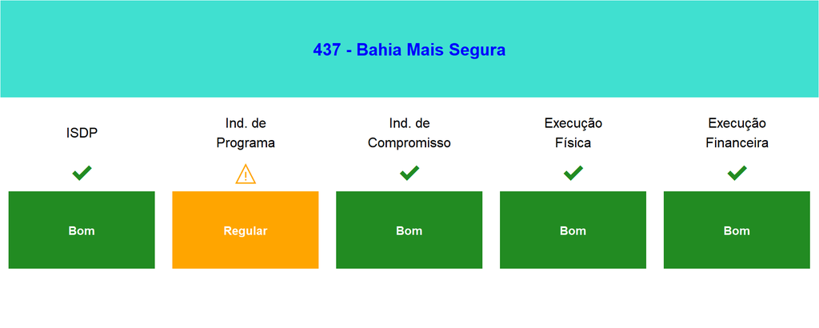

# **2 - Avanços e Conformidades no Programa**

**Indicadores de Programa:** No programa 437 - Bahia Mais Segura, 66,7% dos indicadores apresentaram evolução positiva. O indicador 2266, que mede a taxa de Crimes Violentos Letais Intencionais (CVLI), teve uma melhoria de 28,63%. Essa redução pode ser atribuída a uma otimização das estratégias policiais, como a integração operacional e intensificação de ações e operações. Outro destaque no programa é o indicador 2238, que mede a taxa de vitimização policial fora de serviço, com uma queda de 82,22%, resultado de campanhas internas de conscientização e da diminuição geral da criminalidade.  
**Indicadores de Compromisso:** No programa 437 - Bahia Mais Segura, apenas 47,4% dos indicadores de compromisso foram considerados de bom ou ótimo desempenho. No entanto, o indicador ‘1 - Número de medidas cautelares requeridas pelo Departamento de Repressão e Combate ao Crime Organizado - DRACO’ obteve um notável resultado de 129,17%. Este crescimento deve-se a decisões estratégicas e organizacionais que aprimoraram a capacidade de enfrentamento ao crime. Além disso, a qualificação técnica dos servidores e a superação de entraves institucionais foram cruciais. O indicador ‘4 - Número de serviços de produção da prova material ofertados nas Coordenadorias Regionais de Perícia Técnica’ alcançou 100%, resultado do aporte de recursos financeiros que garantiu a execução das ações planejadas.  
**Ações Orçamentárias:** No Programa 437 - Bahia Mais Segura, 52% das ações obtiveram bom ou ótimo desempenho financeiro, enquanto 66,2% foram consideradas de bom ou ótimo desempenho na execução física. A Ação 4219 - Conservação de Equipamento Especializado da Polícia Técnica e a Ação 2235 - Funcionamento do Serviço de Emissão e Registro de Carteira de Identificação Civil e Criminal apresentaram resultados positivos em ambas as frentes.

# **3 - Oportunidade de Melhoria no Programa**

**Indicadores de Programa:** No programa 437 - Bahia Mais Segura, igualmente, não houve indicadores com evolução negativa, mas o indicador 02232 - Quantidade de municípios autossuficientes para enfrentar eventos desastrosos registrou uma variação de 0%. Isso se deve ao fato de que a construção de cidades resilientes é um processo gradual, e atualmente apenas a capital do estado é considerada autossuficiente nesse aspecto. A evolução desse indicador depende do fortalecimento institucional e operacional da Superintendência de Proteção e Defesa Civil da Bahia – Sudec.  
**Indicadores de Compromisso:** No programa 437 - Bahia Mais Segura, 15,8% dos indicadores de compromisso foram classificados como de desempenho baixo ou muito baixo, enquanto 28,9% apresentaram desempenho indeterminado e 5,3% foram considerados não aptos para avaliação. O indicador ‘1 - Quantidade de salas lilás em operação’ ficou em 37,5%, refletindo ações que ainda estão em processo de execução e foram impactadas pelo atraso na entrega em 2024. Além disso, o indicador ‘2 - Proporção dos Comandos de Policiamento Regionais (CPR) da Polícia Militar Estruturados para o Policiamento Escolar no Interior do Estado’ apresentou um desempenho de 50%. A não superação da meta se deve à priorização de ações estruturantes essenciais para a sustentabilidade do projeto, como a padronização de procedimentos e a capacitação do efetivo policial, o que acabou afetando o cronograma de entrega dos novos núcleos.  
**Ações Orçamentárias:** No entanto, no Programa 437 - Bahia Mais Segura registrou 34,3% de ações com desempenho baixo ou muito baixo na execução financeira e 27,3% na execução física. Um exemplo é a ação 5539 - Aperfeiçoamento de Sistema de Tecnologia da Informação e Comunicação, que foi classificada como “Muito Baixo” na execução financeira e “Regular” na execução física, assim como a ação 3260 - Estruturação de Unidade Operativa de Repressão ao Tráfico de Drogas, que também teve sua classificação como “Muito Baixo”.

Desenvolvido por: DAP – Diretoria de Avaliação de Políticas Públicas